# Tutorial - linear regression

Orlando Sabogal-Cardona

Summer 2023

# 1 Library

```r
library(tidyverse)
library(magrittr)
```

# 2 A simple example

## 2.1 Overview of the data

```r
data("USArrests")
```

```r
names(USArrests)
```

```
[1] "Murder"   "Assault"  "UrbanPop" "Rape"
```

```r
glimpse(USArrests)
```

```
Rows: 50
Columns: 4
$ Murder   <dbl> 13.2, 10.0, 8.1, 8.8, 9.0, 7.9, 3.3, 5.9, 15.4, 17.4, 5.3, 2.6, 10.4, 7.2, 2.2, 6.0…
$ Assault  <int> 236, 263, 294, 190, 276, 204, 110, 238, 335, 211, 46, 120, 249, 113, 56, 115, 109, …
$ UrbanPop <int> 58, 48, 80, 50, 91, 78, 77, 72, 80, 60, 83, 54, 83, 65, 57, 66, 52, 66, 51, 67, 85,…
$ Rape     <dbl> 21.2, 44.5, 31.0, 19.5, 40.6, 38.7, 11.1, 15.8, 31.9, 25.8, 20.2, 14.2, 24.0, 21.0,…
```

## 2.2 Fit the model

Varialble ~ X1 + X2 + X2

```r
Equation <- "Murder ~ Assault + UrbanPop + Rape"

Model <- lm(Equation,
            data = USArrests)
```

## 2.3 General results

```r
summary(Model)
```

```
Call:
lm(formula = Equation, data = USArrests)

Residuals:
    Min      1Q  Median      3Q     Max
-4.3990 -1.9127 -0.3444  1.2557  7.4279

Coefficients:
             Estimate Std. Error t value Pr(>|t|)
(Intercept)  3.276639   1.737997   1.885   0.0657 .
Assault      0.039777   0.005912   6.729 2.33e-08 ***
UrbanPop    -0.054694   0.027880  -1.962   0.0559 .
Rape         0.061399   0.055740   1.102   0.2764
---
Signif. codes:  0 ‘***’ 0.001 ‘**’ 0.01 ‘*’ 0.05 ‘.’ 0.1 ‘ ’ 1

Residual standard error: 2.574 on 46 degrees of freedom
Multiple R-squared:  0.6721,    Adjusted R-squared:  0.6507
F-statistic: 31.42 on 3 and 46 DF,  p-value: 3.322e-11
```

```r
# Murder_ESTIMATED = 3.276639 +
        # 0.039777*Assault + -0.054694*UrbanPop + Rap +  0.061399residual
```

We get from the main output:

- An overview of the residuals
- Parameters: estimates, standard errores, t values, p values, and stars,
- Residual standard errors
- Degrees of freedom
- F-statistics: Used to assess the overall significance of the regression model by testing the null hypothesis that all the regression coefficients (except the intercept) are equal to zero. The F-test provides a measure of whether the linear relationship between the independent variables and the dependent variable is statistically significant.

```r
jtools::summ(Model)
```

```
MODEL INFO:
Observations: 50
Dependent Variable: Murder
Type: OLS linear regression

MODEL FIT:
F(3,46) = 31.42, p = 0.00
R² = 0.67
Adj. R² = 0.65

Standard errors: OLS
------------------------------------------------
                     Est.   S.E.   t val.      p
----------------- ------- ------ -------- ------
(Intercept)          3.28   1.74     1.89   0.07
Assault              0.04   0.01     6.73   0.00
UrbanPop            -0.05   0.03    -1.96   0.06
Rape                 0.06   0.06     1.10   0.28
------------------------------------------------
```

```r
TableResults <- broom::tidy(Model)
TableResults
```

| term | estimate | std.error | statistic | p.value |
| --- | --- | --- | --- | --- |
| (Intercept) | 3.27663918 | 1.737997161 | 1.885296 | 6.571517e-02 |
| Assault | 0.03977717 | 0.005911667 | 6.728587 | 2.328851e-08 |
| UrbanPop | -0.05469363 | 0.027880242 | -1.961734 | 5.586128e-02 |
| Rape | 0.06139942 | 0.055740249 | 1.101528 | 2.763975e-01 |

## 2.4 Zoom in the parameters:

```r
coef(Model)
```

```
(Intercept)     Assault    UrbanPop        Rape
 3.27663918  0.03977717 -0.05469363  0.06139942
```

```r
confint(Model)
```

```
                  2.5 %      97.5 %
(Intercept) -0.22176766 6.775046016
Assault      0.02787760 0.051676734
UrbanPop    -0.11081365 0.001426387
Rape        -0.05079988 0.173598724
```

## 2.5 Diagnostic

### 2.5.1 The plot() function

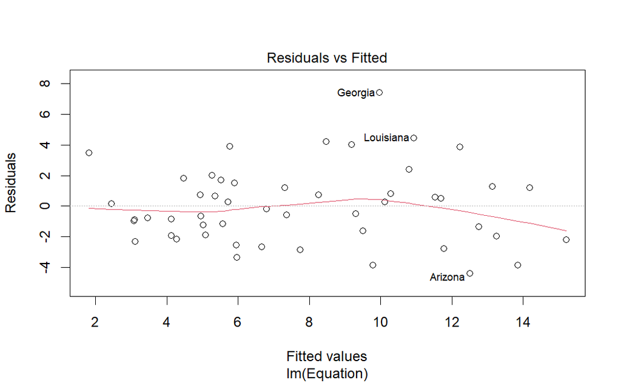

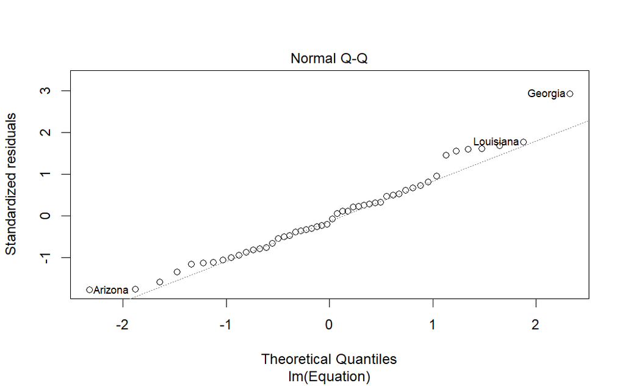

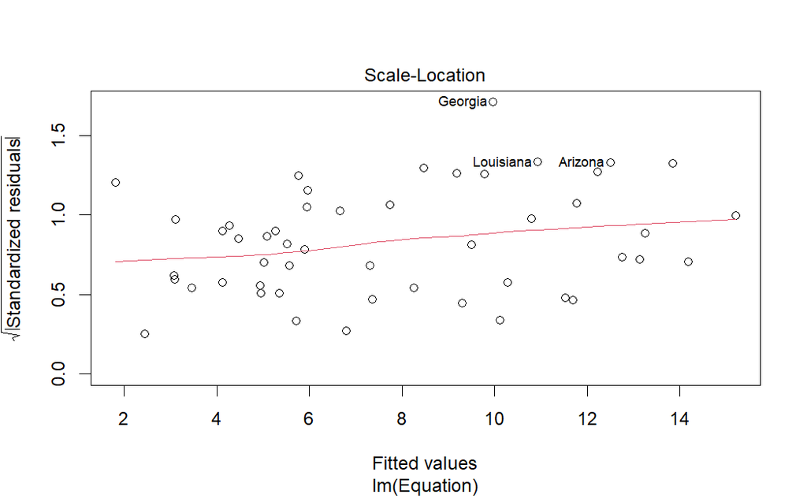

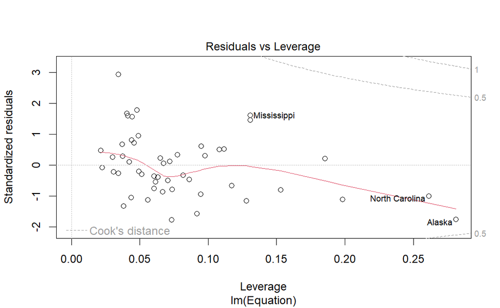

```r
plot(Model)
```

How to interpret these plots?

- **Residuals vs Fitted values:** Check for non-linear patterns. If there are not non-linear relationships in the model we should see residuals equally spread.
- **Normal Q-Q (quantile-quantile) plot:** If the residuals are normally distributed. They should follow a straight line.
- **Root of standardized residuals vs Fitted values (scale-location or spread location plot):** Checks for homoscedasticity, if residuals are spread equally along the ranges of predictors. The vertical axis typically represents the square root of the absolute standardized residuals or the standardized residuals. The square root transformation is applied to stabilize the variance and ensure that negative residuals have meaningful values. Alternatively, the standardized residuals themselves can be used
- **Standardized residuals vs Leverage:** To check for outliers.

## 2.6 Slow down: plots with the residuals

```r
Y_Estimated <- predict(Model)
Residuals <- residuals(Model)

Diagnostic <- data.frame(Y_Estimated, Residuals)

Diagnostic
```

|  | Y_Estimated | Residuals |
| --- | --- | --- |
| Alabama | 10.793487 | 2.4065125 |
| Alaska | 13.845014 | -3.8450138 |
| Arizona | 12.499018 | -4.3990175 |
| Arkansas | 9.296908 | -0.4969079 |
| California | 11.770833 | -2.7708331 |
| Colorado | 9.501235 | -1.6012355 |
| Connecticut | 4.122251 | -0.8222515 |
| Delaware | 9.775774 | -3.8757741 |
| Florida | 14.185141 | 1.2148592 |
| Georgia | 9.972108 | 7.4278916 |

[output cut: 40 more lines]

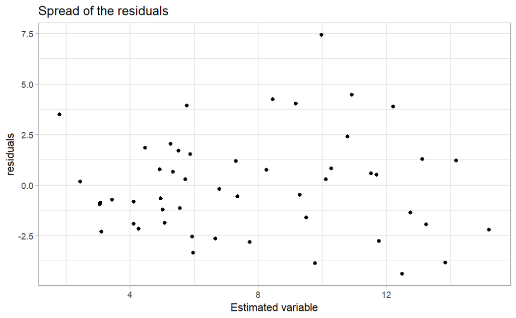

```r
ggplot(data = Diagnostic) +
  geom_point(aes(x = Y_Estimated, y = Residuals)) +
  ggtitle("Spread of the residuals") +
  xlab("Estimated variable") + ylab("residuals") +
  theme_light()
```

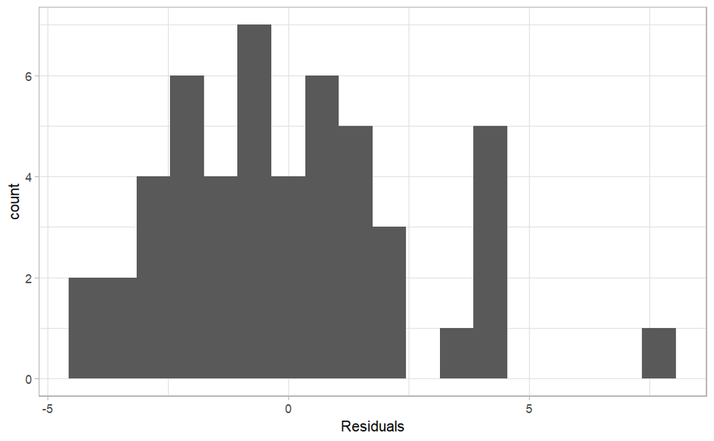

```r
ggplot(data = Diagnostic) +
  geom_histogram(aes(x = Residuals), binwidth = 0.7) +
  theme_light()
```

## 2.7 QQ Plots

```r
Diagnostic %<>% arrange(Residuals)
Diagnostic
```

|  | Y_Estimated | Residuals |
| --- | --- | --- |
| Arizona | 12.499018 | -4.3990175 |
| Delaware | 9.775774 | -3.8757741 |
| Alaska | 13.845014 | -3.8450138 |
| Idaho | 5.968315 | -3.3683148 |
| Oregon | 7.735738 | -2.8357384 |
| California | 11.770833 | -2.7708331 |
| Washington | 6.660358 | -2.6603581 |
| Rhode Island | 5.949135 | -2.5491354 |
| North Dakota | 3.108308 | -2.3083077 |
| North Carolina | 15.208861 | -2.2088613 |

[output cut: 40 more lines]

```r
Observations <- dim(USArrests)[1]
Probabilities <- seq(0.01, 0.99, 0.02)
Probabilities <- (1:Observations - 0.5)/Observations

Diagnostic %<>% mutate(Theoretical_Quantiles = qnorm(Probabilities))
Diagnostic
```

|  | Y_Estimated | Residuals | Theoretical_Quantiles |
| --- | --- | --- | --- |
| Arizona | 12.499018 | -4.3990175 | -2.32634787 |
| Delaware | 9.775774 | -3.8757741 | -1.88079361 |
| Alaska | 13.845014 | -3.8450138 | -1.64485363 |
| Idaho | 5.968315 | -3.3683148 | -1.47579103 |
| Oregon | 7.735738 | -2.8357384 | -1.34075503 |
| California | 11.770833 | -2.7708331 | -1.22652812 |
| Washington | 6.660358 | -2.6603581 | -1.12639113 |
| Rhode Island | 5.949135 | -2.5491354 | -1.03643339 |
| North Dakota | 3.108308 | -2.3083077 | -0.95416525 |
| North Carolina | 15.208861 | -2.2088613 | -0.87789630 |

[output cut: 40 more lines]

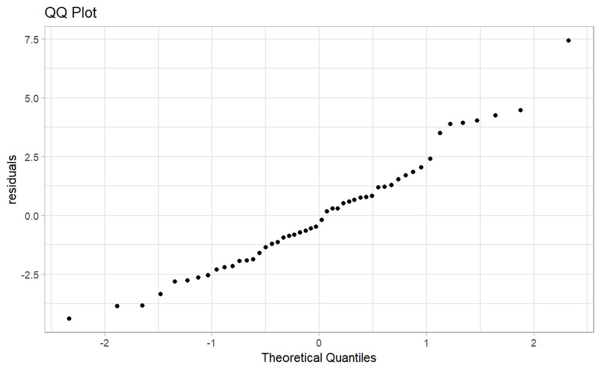

```r
ggplot(data = Diagnostic) +
  geom_point(aes(x = Theoretical_Quantiles, y = Residuals)) +
  ggtitle("QQ Plot") +
  xlab("Theoretical Quantiles") + ylab("residuals") +
  theme_light()
```

```r
Model$df.residual
```

```
[1] 46
```

```r
estimated_sd <- sqrt(sum(Diagnostic$Residuals^2)/Model$df.residual)

Diagnostic %<>% mutate(Stand_Residuals = Residuals/estimated_sd)
Diagnostic
```

|  | Y_Estimated | Residuals | Theoretical_Quantiles | Stand_Residuals |
| --- | --- | --- | --- | --- |
| Arizona | 12.499018 | -4.3990175 | -2.32634787 | -1.70885069 |
| Delaware | 9.775774 | -3.8757741 | -1.88079361 | -1.50559055 |
| Alaska | 13.845014 | -3.8450138 | -1.64485363 | -1.49364133 |
| Idaho | 5.968315 | -3.3683148 | -1.47579103 | -1.30846196 |
| Oregon | 7.735738 | -2.8357384 | -1.34075503 | -1.10157630 |
| California | 11.770833 | -2.7708331 | -1.22652812 | -1.07636307 |
| Washington | 6.660358 | -2.6603581 | -1.12639113 | -1.03344774 |
| Rhode Island | 5.949135 | -2.5491354 | -1.03643339 | -0.99024197 |
| North Dakota | 3.108308 | -2.3083077 | -0.95416525 | -0.89668958 |
| North Carolina | 15.208861 | -2.2088613 | -0.87789630 | -0.85805845 |

[output cut: 40 more lines]

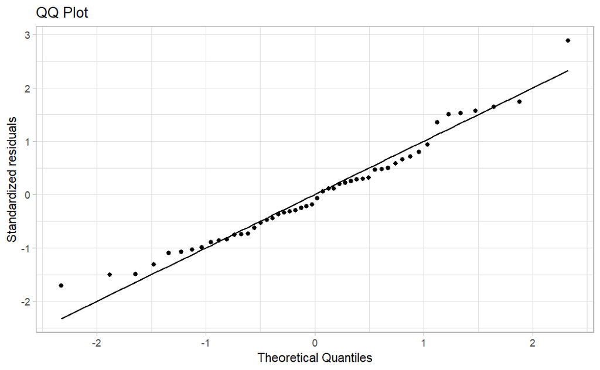

```r
ggplot(data = Diagnostic) +
  geom_point(aes(x = Theoretical_Quantiles, y = Stand_Residuals)) +
  geom_line(aes(x = Theoretical_Quantiles, y = Theoretical_Quantiles)) +
  ggtitle("QQ Plot") +
  xlab("Theoretical Quantiles") + ylab("Standardized residuals") +
  theme_light()
```

## 2.8 Scale-location plot

```r
Diagnostic %<>%
  mutate(sqrt_abs_std_resid = sqrt(abs(Stand_Residuals)) )

Diagnostic
```

|  | Y_Estimated | Residuals | Theoretical_Quantiles | Stand_Residuals | sqrt_abs_std_resid |
| --- | --- | --- | --- | --- | --- |
| Arizona | 12.499018 | -4.3990175 | -2.32634787 | -1.70885069 | 1.3072302 |
| Delaware | 9.775774 | -3.8757741 | -1.88079361 | -1.50559055 | 1.2270251 |
| Alaska | 13.845014 | -3.8450138 | -1.64485363 | -1.49364133 | 1.2221462 |
| Idaho | 5.968315 | -3.3683148 | -1.47579103 | -1.30846196 | 1.1438802 |
| Oregon | 7.735738 | -2.8357384 | -1.34075503 | -1.10157630 | 1.0495601 |
| California | 11.770833 | -2.7708331 | -1.22652812 | -1.07636307 | 1.0374792 |
| Washington | 6.660358 | -2.6603581 | -1.12639113 | -1.03344774 | 1.0165863 |
| Rhode Island | 5.949135 | -2.5491354 | -1.03643339 | -0.99024197 | 0.9951090 |
| North Dakota | 3.108308 | -2.3083077 | -0.95416525 | -0.89668958 | 0.9469369 |
| North Carolina | 15.208861 | -2.2088613 | -0.87789630 | -0.85805845 | 0.9263144 |

[output cut: 40 more lines]

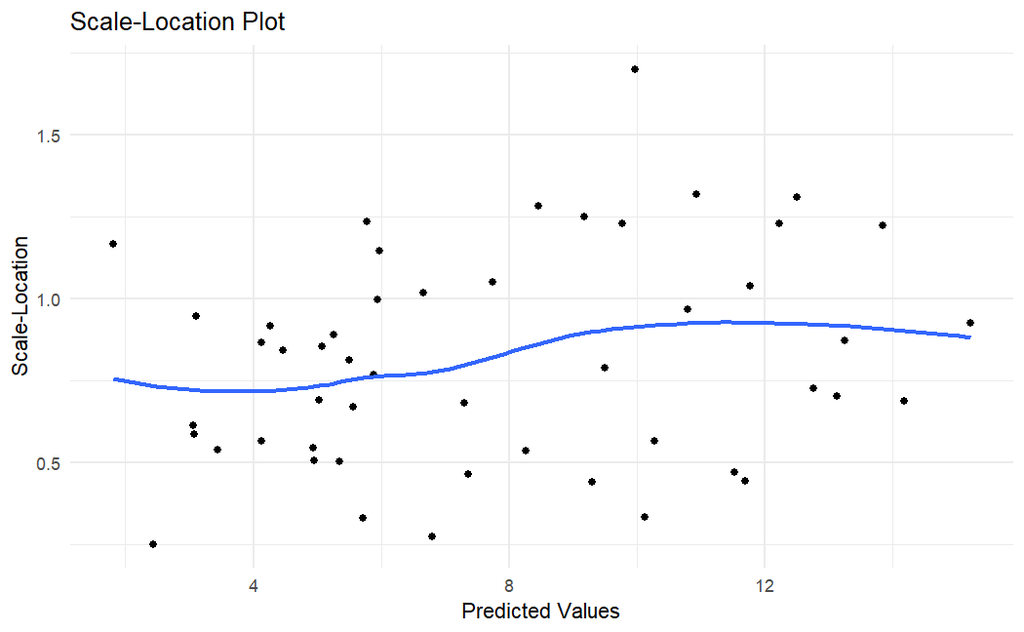

```r
ggplot(Diagnostic, aes(x = Y_Estimated, y = sqrt_abs_std_resid)) +
  geom_point() +
  geom_smooth(method = "loess", se = FALSE) +
  labs(x = "Predicted Values", y = "Scale-Location") +
  ggtitle("Scale-Location Plot") +
  theme_minimal()
```

## 2.9 Leverage

The leverage plot, also known as the leverage-residuals plot or the Cook’s distance plot, is a diagnostic plot used in linear regression analysis. It helps identify influential observations that have a significant impact on the regression model’s results.

Leverage refers to the potential of an observation to have a disproportionate effect on the estimated regression coefficients. Observations with high leverage can have a substantial impact on the regression line, either by exerting a pulling effect or by being outliers.

In the leverage plot, each point represents an observation from the dataset. The vertical axis shows the standardized residuals, which indicate how far each observation’s actual value deviates from its predicted value, taking into account the variability of the residuals. The horizontal axis represents the leverage values of the observations, which measure the potential influence of each observation on the estimated regression coefficients.

Leverage values are calculated using the “*Hat*” matrix, which is a matrix that maps the observed values to the predicted values. High leverage values suggest that an observation has a greater ability to affect the estimated regression coefficients. Observations with high leverage are located towards the ends of the horizontal axis.

Influential Observations: Observations with high leverage and large residuals can be considered influential observations. They have the potential to significantly affect the regression model’s parameters and can distort the results if they are outliers or if their predictors have extreme values.

Cook’s Distance: In addition to the leverage plot, Cook’s distance is often shown on the same graph or as a separate plot. Cook’s distance measures the influence of each observation on the entire regression model. Large values of Cook’s distance suggest influential observations that significantly affect the regression model’s results.

By examining the leverage plot and Cook’s distance, you can identify influential observations that may require further investigation. These observations may have a substantial impact on the regression analysis and could potentially affect the model’s conclusions.

It’s important to note that the interpretation of influential observations should be done cautiously, considering the context and objectives of the analysis. Influential observations may warrant additional scrutiny, but they should not be automatically removed without careful consideration and justification.